# W2D3

```python
from IPython.display import Image
```

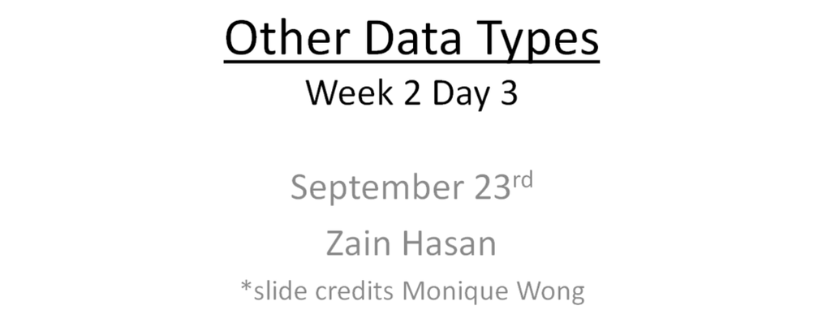

```python
Image(filename='1.PNG')
```

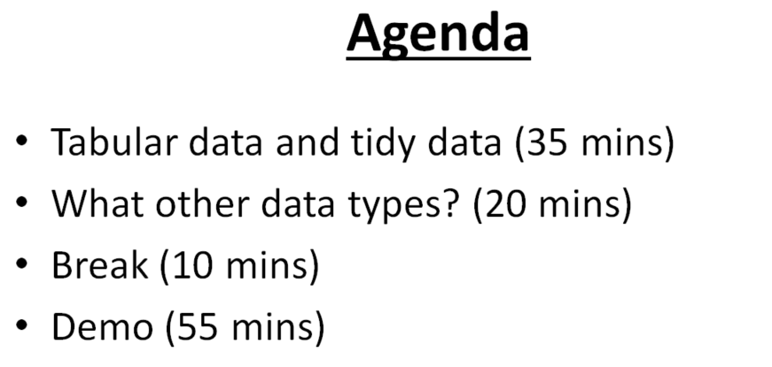

```python
Image(filename='2.PNG')
```

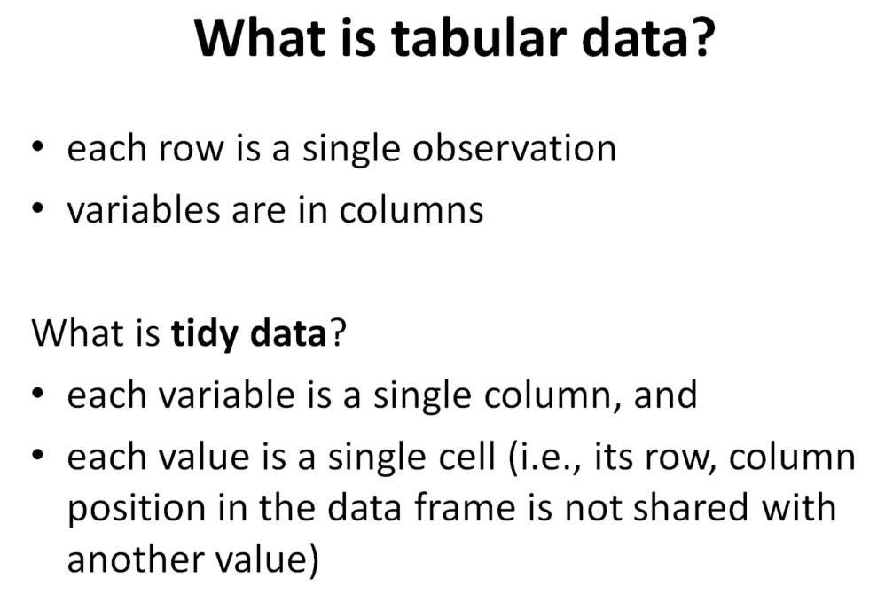

```python
Image(filename='3.PNG')
```

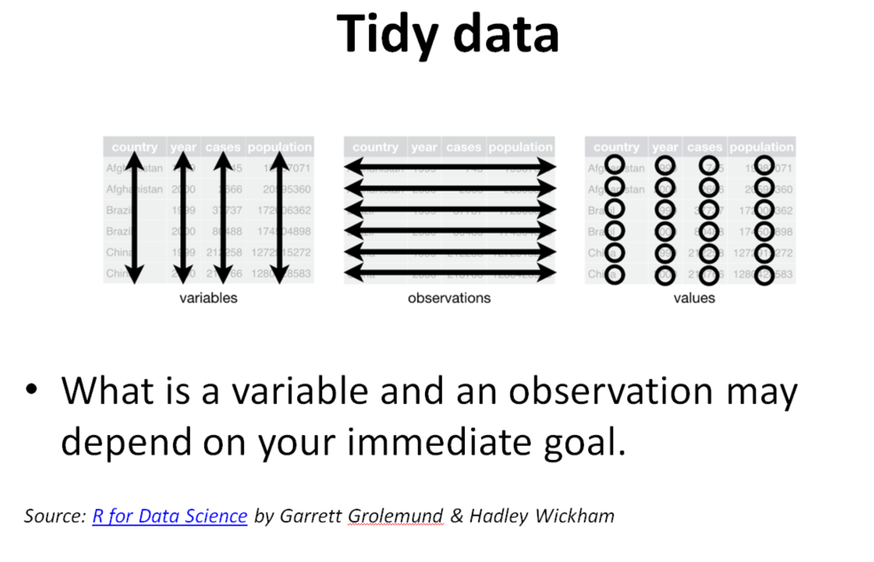

```python
Image(filename='4.PNG')
```

## Is the example tidy? (1)

*Example source: https://garrettgman.github.io/tidying/*

**Question: What variables are associated with the number of TB cases?**

This data is tidy, true or false?

| country | year | cases_per_capita |
| --- | --- | --- |
| Afghanistan | 1999 | 745/19987071 |
| Afghanistan | 2000 | 2666/20595360 |
| Brazil | 1999 | 37737/172006362 |
| Brazil | 2000 | 80488/174504898 |
| China | 1999 | 212258/1272915272 |
| China | 2000 | 213766/1280428583 |

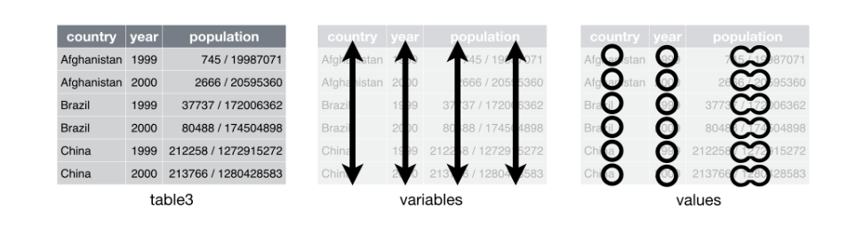

```python
Image(filename='t1.PNG')
```

## Is the example tidy? (2)

**Question: What variables are associated with the number of TB cases?**

This data is tidy, true or false?

| country | cases (year=1999) | cases (year=2000) | population (year=1999) | population (year=2000) |
| --- | --- | --- | --- | --- |
| Afghanistan | 745 | 2666 | 19987071 | 20595360 |
| Brazil | 37737 | 80488 | 172006362 | 174504898 |
| China | 212258 | 213766 | 1272915272 | 1280428583 |

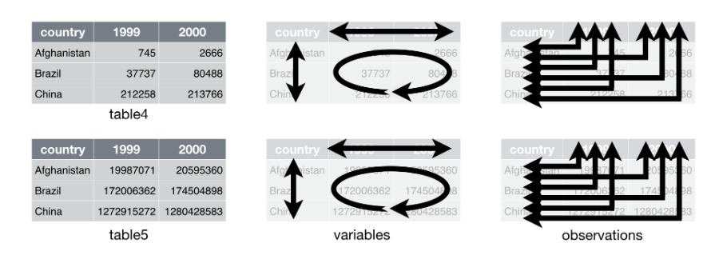

```python
Image(filename='t2.PNG')
```

## Is the example tidy? (3)

**Question: What variables are associated with the number of TB cases?**

This data is tidy, true or false?

| country | year | cases | population |
| --- | --- | --- | --- |
| Afghanistan | 1999 | 745 | 19987071 |
| Afghanistan | 2000 | 2666 | 20595360 |
| Brazil | 1999 | 37737 | 172006362 |
| Brazil | 2000 | 80488 | 174504898 |
| China | 1999 | 212258 | 1272915272 |
| China | 2000 | 213766 | 1280428583 |

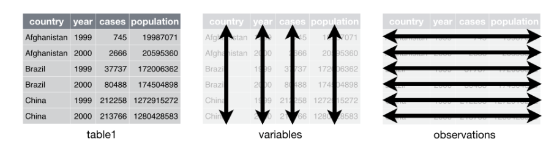

```python
Image(filename='t3.PNG')
```

## Is the example tidy? (4)

**Question: What variables are associated with the number of TB cases?**

This data is tidy, true or false?

| country | year | key | value |
| --- | --- | --- | --- |
| Afghanistan | 1999 | cases | 745 |
| Afghanistan | 1999 | population | 19987071 |
| Afghanistan | 2000 | cases | 2666 |
| Afghanistan | 2000 | population | 20595360 |
| Brazil | 1999 | cases | 37737 |
| Brazil | 1999 | population | 172006362 |
| Brazil | 2000 | cases | 80488 |
| Brazil | 2000 | population | 174504898 |
| China | 1999 | cases | 212258 |
| China | 1999 | population | 1272915272 |
| China | 2000 | cases | 213766 |
| China | 2000 | population | 1280428583 |

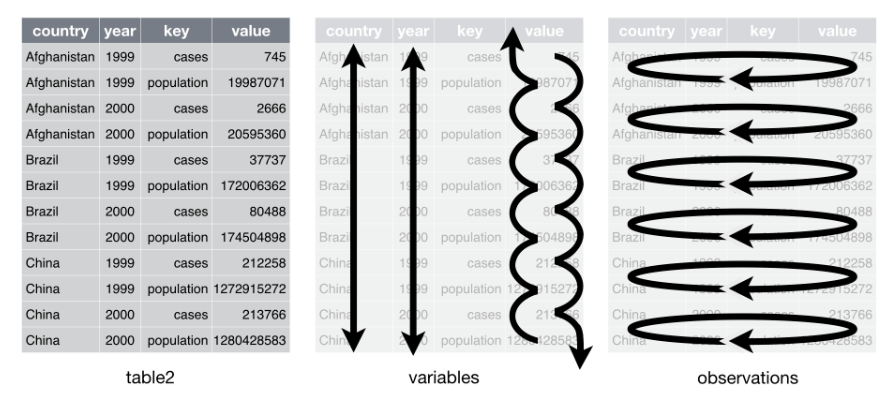

```python
Image(filename='t4.PNG')
```

## What other types of data is useful to data scientists?

Exercise: Let's fill out this table together.

| Data Type | Example | What are we trying to use it for? |
| --- | --- | --- |
| Text | Tweets, scripts, books | Sentiment analysis, other NLP |
| JSON or XML | Parsing APIs | Gather data, data ingestion process, trend analysis, forecasting |
| HTML | Web scraping | Get prices of different products, Facebook / LinkedIn contacts and work history |
| Excel | BoM's | Financial data, etc. |
| Images | Computer vision | Self-driving cars, building custom shoes, X-rays - diagnostics |
| Time Series | Speech analysis | Speech-to-text, medical signal analysis, sensor input analysis |

- Text: will be covered in more detail when we're doing Natural Language Processing (NLP)
- **JSON: we already covered, we'll talk a bit more about it today**
- **XML and HTML: We'll talk through today**
- **Excel: We'll cover today**
- Images: will be covered in more detail when we're doing Convolutional Neural Networks (CNNs)
- Time Series: will be covered later after we cover NLP

## Data science intro to XML and HTML

- hierarchical collection of elements
- element consists of **start tag**, **content** and **end tag**, and **attributes**
- tags have names and are delimited with `<` and `>`; end tag with `</ >`
- attributes added after the tag name within `<` and `>`

For example: `<country name="Canada">` content content `</country>`

- `country` is the tag
- `name="Canada"` is an attribute

**HTML is just XML for webpages.**

## Let's see a HTML example

Let's take a look at an example: https://en.wikipedia.org/wiki/List_of_FIFA_World_Cup_winners

- Use inspect page to see HTML
- Explain header, body, tags etc.

## Let's see an Excel example

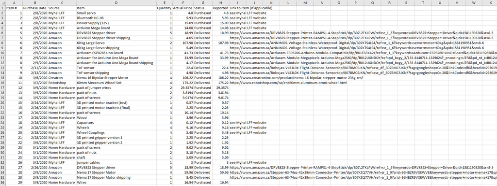

```python
Image(filename='excel.PNG')
```

## JSON - https://www.json.org/json-en.html

- Basically a way to store, serve, transport information in the form/syntax of Java Script Objects == Python Dictionaries
- JSON exists as a string — useful when you want to transmit data across a network.
- JSON is purely a data format — it contains only properties, no methods.
- JSON requires double quotes to be used around strings and property names. Single quotes are not valid.

# Break

10 mins

## Different data, different tools

We will demo these.

## Tabular data using pandas

```python
import pandas as pd
```

```python
wine_csv = pd.read_csv('data/wine.csv')
wine_csv
```

|  | Bottle | Grape | Origin | Alcohol | pH | Colour | Aroma |
| --- | --- | --- | --- | --- | --- | --- | --- |
| 0 | 1 | Chardonnay | Australia | 14.23 | 3.51 | White | Floral |
| 1 | 2 | Pinot Grigio | Italy | 13.20 | 3.30 | White | Fruity |
| 2 | 3 | Pinot Blanc | France | 13.16 | 3.16 | White | Citrus |
| 3 | 4 | Shiraz | Chile | 14.91 | 3.39 | Red | Berry |
| 4 | 5 | Malbec | Argentina | 13.83 | 3.28 | Red | Fruity |

```python
wine_xlsx = pd.read_excel('data/wine.xlsx')
wine_xlsx
```

|  | Bottle | Grape | Origin | Alcohol | pH | Colour | Aroma |
| --- | --- | --- | --- | --- | --- | --- | --- |
| 0 | 1 | Chardonnay | Australia | 14.23 | 3.51 | White | Floral |
| 1 | 2 | Pinot Grigio | Italy | 13.20 | 3.30 | White | Fruity |
| 2 | 3 | Pinot Blanc | France | 13.16 | 3.16 | White | Citrus |
| 3 | 4 | Shiraz | Chile | 14.91 | 3.39 | Red | Berry |
| 4 | 5 | Malbec | Argentina | 13.83 | 3.28 | Red | Fruity |

## Python and Excel

- They are complementary! It's not a competition
- Uses for both
- For example:

```python
wine_2 = pd.read_excel('data/wine_2.xlsx')
wine_2
```

|  | This workbook contains data for different wines |
| --- | --- |
| 0 | Created by John Smith |

- What's wrong?

## Python and Excel ... continued

- If I opened the Excel, I would find out that the useful data is on Sheet 2

```python
wine_2 = pd.read_excel('data/wine_2.xlsx', sheet_name=1) # here, I reference the sheet name
wine_2
```

|  | Bottle | Grape | Origin | Alcohol | pH | Colour | Aroma |
| --- | --- | --- | --- | --- | --- | --- | --- |
| 0 | 1 | Chardonnay | Australia | 14.23 | 3.51 | White | Floral |
| 1 | 2 | Pinot Grigio | Italy | 13.20 | 3.30 | White | Fruity |
| 2 | 3 | Pinot Blanc | France | 13.16 | 3.16 | White | Citrus |
| 3 | 4 | Shiraz | Chile | 14.91 | 3.39 | Red | Berry |
| 4 | 5 | Malbec | Argentina | 13.83 | 3.28 | Red | Fruity |

## JSON

Here's some sample JSON: https://raw.githubusercontent.com/chrisalbon/simulated_datasets/master/data.json

```python
# You can read from the URL too!!
url = 'https://raw.githubusercontent.com/chrisalbon/simulated_datasets/master/data.json'
json_data = pd.read_json(url)
json_data.head()
```

|  | integer | datetime | category |
| --- | --- | --- | --- |
| 0 | 5 | 2015-01-01 00:00:00 | 0 |
| 1 | 5 | 2015-01-01 00:00:01 | 0 |
| 2 | 9 | 2015-01-01 00:00:02 | 0 |
| 3 | 6 | 2015-01-01 00:00:03 | 0 |
| 4 | 6 | 2015-01-01 00:00:04 | 0 |

```python
#Another Example

json_data = pd.read_json('data/users.json')
json_data
```

|  | sammy | jesse | drew | jamie |
| --- | --- | --- | --- | --- |
| username | SammyShark | JesseOctopus | DrewSquid | JamieMantisShrimp |
| location | Indian Ocean | Pacific Ocean | Atlantic Ocean | Pacific Ocean |
| online | True | False | False | True |
| followers | 987 | 432 | 321 | 654 |

## JSON ... continued

- `pd.read_json` doesn't work so well with nested JSON...
- Let's take a look at what a nested JSON is...

```python
# an error is supposed to happen when you run this cell

nested_json = pd.read_json('data/nested.json')
nested_json
```

[output not shown]

[output cut: 24 more lines]

[output not shown]

## JSON ... continued

- Instead, you can try this:

```python
import json

with open('data/nested.json') as file:
    nested_json = json.load(file)

nested_json
```

```
{'article': [{'id': '01',
   'language': 'JSON',
   'edition': 'first',
   'author': 'Allen'},
  {'id': '02',
   'language': 'Python',
   'edition': 'second',
   'author': 'Aditya Sharma'}],
 'blog': [{'name': 'Datacamp', 'URL': 'datacamp.com'}]}
```

- What is the type?

```python
type(nested_json)
```

```
dict
```

## XML

- Let's take a look at an XML file: https://drive.google.com/file/d/1Nfq42ss8jIqajaAOVdwzW4D3D5oL7Y2t/view
- We use the `xml` package to work with XML

```python
import xml.etree.ElementTree as et
```

```python
# parses the XML so that it figures out the "tree" of tags
tree = et.parse('data/data.xml')
tree
```

```
<xml.etree.ElementTree.ElementTree at 0x17166dcf7b8>
```

```python
# get to the root tag of the file
root = tree.getroot()
root
```

```
<Element 'data' at 0x17166e1ea20>
```

## XML ... continued

From the root, we can begin to navigate the tree

```python
# get root tag
print("What is the root tag:", root.tag)

# get root attributes
print("Attributes of the root tag:", root.attrib)

# get number of "children"
print("Number of children:", len(root))
```

```
What is the root tag: data
Attributes of the root tag: {}
Number of children: 3
```

```python
# printing out the children of root
for idx in range(len(root)):
    print("tag:", root[idx].tag, "| attribute:", root[idx].attrib)
```

```
tag: country | attribute: {'name': 'Liechtenstein'}
tag: country | attribute: {'name': 'Singapore'}
tag: country | attribute: {'name': 'Panama'}
```

## XML ... continued

Let's continue exploring...

```python
country1 = root[0]
rank = country1[0]

print(country1.attrib)
print(rank.tag, ":", rank.text)
```

```
{'name': 'Liechtenstein'}
rank : 1
```

### Get the neighbour of the 2nd country

```python
country2 = root[1]
neighbour = country2[3]

print(country2.attrib['name'],'has neighbour',neighbour.attrib['name'])
```

```
Singapore has neighbour Malaysia
```

Can you follow where we got to on the `data.xml` file?

## JSON tutorial

```python
from pandas import json_normalize
```

```python
nested_json
```

```
{'article': [{'id': '01',
   'language': 'JSON',
   'edition': 'first',
   'author': 'Allen'},
  {'id': '02',
   'language': 'Python',
   'edition': 'second',
   'author': 'Aditya Sharma'}],
 'blog': [{'name': 'Datacamp', 'URL': 'datacamp.com'}]}
```

```python
json_normalize(nested_json)
```

|  | article | blog |
| --- | --- | --- |
| 0 | [{'id': '01', 'language': 'JSON', 'edition': '... | [{'name': 'Datacamp', 'URL': 'datacamp.com'}] |

```python
blog = json_normalize(nested_json, record_path='blog')
blog.head()
```

|  | name | URL |
| --- | --- | --- |
| 0 | Datacamp | datacamp.com |

```python
article = json_normalize(nested_json,record_path ='article')
article.head()
```

|  | id | language | edition | author |
| --- | --- | --- | --- | --- |
| 0 | 01 | JSON | first | Allen |
| 1 | 02 | Python | second | Aditya Sharma |

```python
data = [{"state": "Florida",
        "shortname": "FL",
        "info": {"governor": "Rick Scott"},
        "counties": [{"name": "Dade", "population": 12345},
                     {"name": "Broward", "population": 40000},
                     {"name": "Palm Beach", "population": 60000}]},
       {"state": "Ohio",
        "shortname": "OH",
        "info": {"governor": "John Kasich"},
        "counties": [{"name": "Summit", "population": 1234},
                     {"name": "Cuyahoga", "population": 1337}]}]
```

```python
json_normalize(data)
json_normalize(data=data, record_path='counties', meta=['state', 'shortname', ['info', 'governor']])
```

|  | name | population | state | shortname | info.governor |
| --- | --- | --- | --- | --- | --- |
| 0 | Dade | 12345 | Florida | FL | Rick Scott |
| 1 | Broward | 40000 | Florida | FL | Rick Scott |
| 2 | Palm Beach | 60000 | Florida | FL | Rick Scott |
| 3 | Summit | 1234 | Ohio | OH | John Kasich |
| 4 | Cuyahoga | 1337 | Ohio | OH | John Kasich |

```python
json_normalize(data=data, meta=['state', 'shortname'])
```

|  | state | shortname | counties | info.governor |
| --- | --- | --- | --- | --- |
| 0 | Florida | FL | [{'name': 'Dade', 'population': 12345}, {'name... | Rick Scott |
| 1 | Ohio | OH | [{'name': 'Summit', 'population': 1234}, {'nam... | John Kasich |

```python
import bs4 as bs    #Beautiful soup
import urllib.request
```

```python
source = urllib.request.urlopen('https://en.wikipedia.org/wiki/List_of_FIFA_World_Cup_winning_players').read()
```

```python
soup = bs.BeautifulSoup(source,'html')
```

```python
# title of the page
print(soup.title)

# get attributes:
print(soup.title.name)

# get values:
print(soup.title.string)

# beginning navigation:
print(soup.title.parent.name)

# getting specific values:
print(soup.p)
```

```
<title>List of FIFA World Cup winning players - Wikipedia</title>
title
List of FIFA World Cup winning players - Wikipedia
head
<p>This is a list of all players who have won the <a href="/wiki/FIFA_World_Cup" title="FIFA World Cup">FIFA World Cup</a> tournament since its inception in 1930.
</p>
```